# 21099hw

Yanlin Hu

2021-12-20

## HW1

## Question

Use knitr to produce at least 3 examples(texts,figures,tables)

## Answer

### Example 1 (text)

哈哈哈

### Example 2 (figures)

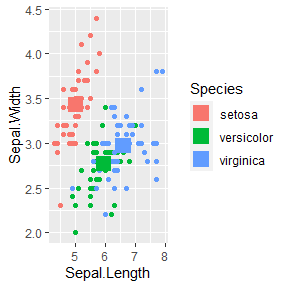

```r
library(ggplot2)
iris.summary <- aggregate(iris[1:4], list(iris$Species), mean)
names(iris.summary)[1] <- 'Species'
ggplot(iris, aes(x = Sepal.Length, y = Sepal.Width, col = Species)) + geom_point() + geom_point(data = iris.summary, shape = 15, size = 5)
```

### Example 3 (tables)

```r
head(iris)
```

```
##   Sepal.Length Sepal.Width Petal.Length Petal.Width Species
## 1          5.1         3.5          1.4         0.2  setosa
## 2          4.9         3.0          1.4         0.2  setosa
## 3          4.7         3.2          1.3         0.2  setosa
## 4          4.6         3.1          1.5         0.2  setosa
## 5          5.0         3.6          1.4         0.2  setosa
## 6          5.4         3.9          1.7         0.4  setosa
```

```r
library(kableExtra)
data<-head(iris)
data %>%
  kbl(caption = "table of iris") %>%
  kable_classic(full_width = F, html_font = "Cambria")
```

table of iris

| Sepal.Length | Sepal.Width | Petal.Length | Petal.Width | Species |
| --- | --- | --- | --- | --- |
| 5.1 | 3.5 | 1.4 | 0.2 | setosa |
| 4.9 | 3.0 | 1.4 | 0.2 | setosa |
| 4.7 | 3.2 | 1.3 | 0.2 | setosa |
| 4.6 | 3.1 | 1.5 | 0.2 | setosa |
| 5.0 | 3.6 | 1.4 | 0.2 | setosa |
| 5.4 | 3.9 | 1.7 | 0.4 | setosa |

## Hw2

## Question

Exercises 3.4 3.11, and 3.20

## Answer

### 3.4

这个一看就比较适合用Inverse transformation method来做,我们先求其分布函数: $F(x)=\int_{0}^{x}f(t)dt=\int_{0}^{x}\frac{t}{\sigma^2}e^{-\frac{t^2}{2\sigma^2}}dt=\int_{0}^{x}\frac{1}{\sigma^2}e^{-\frac{t^2}{2\sigma^2}}d(\frac{t^2}{2})=\int_{0}^{\frac{x^2}{2}}\frac{1}{\sigma^2}e^{-\frac{u}{\sigma^2}}du=1-e^{-\frac{x^2}{2\sigma^2}}$,然后求逆: $F(x)=t \Rightarrow 1-e^{-\frac{x^2}{2\sigma^2}}=t \Rightarrow x=\sigma\sqrt{-2ln(1-t)}$ 下面生成几组不同的Rayleigh($\sigma$) samples

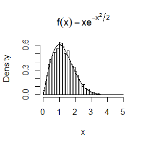

```r
n <- 2000
u <- runif(n)
sigma=1   # sigma=1
x=sigma*sqrt(-2*log(1-u))
hist(x, prob = TRUE, breaks=c(0:50)/10, main = expression(f(x)==x*e^{-x^2/2}))
y <- seq(0, 5, .01)
lines(y,(y/sigma^2)*exp(-y^2/(2*sigma^2)))
```

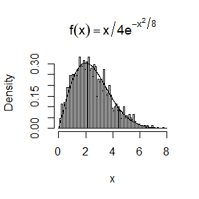

```r
n <- 2000
u <- runif(n)
sigma=2   # sigma=2
x=sigma*sqrt(-2*log(1-u))
ran<-floor(range(x)[2])+1
hist(x, prob = TRUE, breaks=c(0:(ran*10))/10, main = expression(f(x)==x/4*e^{-x^2/8}))
y <- seq(0, ran, .01)
lines(y,(y/sigma^2)*exp(-y^2/(2*sigma^2)))
```

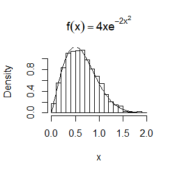

```r
n <- 2000
u <- runif(n)
sigma=0.5   # sigma=0.5
x=sigma*sqrt(-2*log(1-u))
ran<-floor(range(x)[2])+1
hist(x, prob = TRUE, breaks=c(0:(ran*10))/10, main = expression(f(x)==4*x*e^{-2*x^2}))
y <- seq(0, ran, .01)
lines(y,(y/sigma^2)*exp(-y^2/(2*sigma^2)))
```

### 3.11

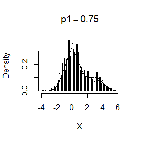

```r
p1<-0.75
p2<-1-p1
n<-1000
u<-runif(n)
X1<-rnorm(n,0,1)
X2<-rnorm(n,3,1)
X<-rep(0,n)
for(i in 1:n){
  if(u[i]<=p1){
    X[i]<-X1[i]
  }
  else{X[i]<-X2[i]}
}
ran1<-floor(range(X)[1])
ran2<-floor(range(X)[2])+1
hist(X,prob = TRUE, breaks=c((ran1*10):(ran2*10))/10,main = expression(p1==0.75))
y <- seq(ran1, ran2, .01)
lines(y,p1*dnorm(y,0,1)+p2*dnorm(y,3,1))
```

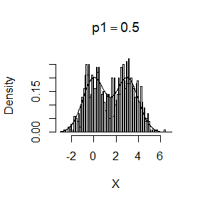

```r
p1<-0.5
p2<-1-p1
n<-1000
u<-runif(n)
X1<-rnorm(n,0,1)
X2<-rnorm(n,3,1)
X<-rep(0,n)
for(i in 1:n){
  if(u[i]<=p1){
    X[i]<-X1[i]
  }
  else{X[i]<-X2[i]}
}
ran1<-floor(range(X)[1])
ran2<-floor(range(X)[2])+1
hist(X,prob = TRUE, breaks=c((ran1*10):(ran2*10))/10,main = expression(p1==0.5))
y <- seq(ran1, ran2, .01)
lines(y,p1*dnorm(y,0,1)+p2*dnorm(y,3,1))
```

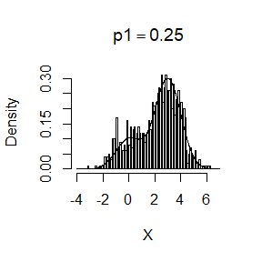

```r
p1<-0.25
p2<-1-p1
n<-1000
u<-runif(n)
X1<-rnorm(n,0,1)
X2<-rnorm(n,3,1)
X<-rep(0,n)
for(i in 1:n){
  if(u[i]<=p1){
    X[i]<-X1[i]
  }
  else{X[i]<-X2[i]}
}
ran1<-floor(range(X)[1])
ran2<-floor(range(X)[2])+1
hist(X,prob = TRUE, breaks=c((ran1*10):(ran2*10))/10,main = expression(p1==0.25))
y <- seq(ran1, ran2, .01)
lines(y,p1*dnorm(y,0,1)+p2*dnorm(y,3,1))
```

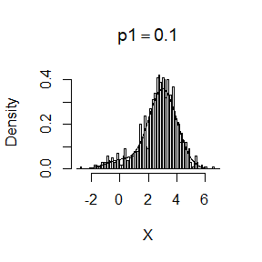

```r
p1<-0.1
p2<-1-p1
n<-1000
u<-runif(n)
X1<-rnorm(n,0,1)
X2<-rnorm(n,3,1)
X<-rep(0,n)
for(i in 1:n){
  if(u[i]<=p1){
    X[i]<-X1[i]
  }
  else{X[i]<-X2[i]}
}
ran1<-floor(range(X)[1])
ran2<-floor(range(X)[2])+1
hist(X,prob = TRUE, breaks=c((ran1*10):(ran2*10))/10,main = expression(p1==0.1))
y <- seq(ran1, ran2, .01)
lines(y,p1*dnorm(y,0,1)+p2*dnorm(y,3,1))
```

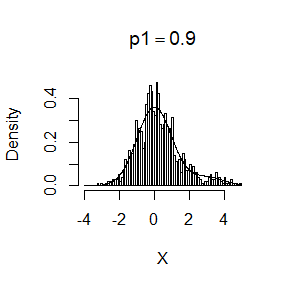

```r
p1<-0.9
p2<-1-p1
n<-1000
u<-runif(n)
X1<-rnorm(n,0,1)
X2<-rnorm(n,3,1)
X<-rep(0,n)
for(i in 1:n){
  if(u[i]<=p1){
    X[i]<-X1[i]
  }
  else{X[i]<-X2[i]}
}
ran1<-floor(range(X)[1])
ran2<-floor(range(X)[2])+1
hist(X,prob = TRUE, breaks=c((ran1*10):(ran2*10))/10,main = expression(p1==0.9))
y <- seq(ran1, ran2, .01)
lines(y,p1*dnorm(y,0,1)+p2*dnorm(y,3,1))
```

$p_1$太大或者太小都没有双峰出现,$p_1=p_2$的时候双峰最明显.

### 3.20

我们先求一下$X(t)$的理论期望和方差: $E(X_t)=E[E(X_t|N_t)]=E[E(\sum_{i=1}^{N_t}Y_i|N_t)]=E[N_tE(Y)]=E(N_t)E(Y)=\lambda t E(Y)$, 这是由于$N_t$服从参数为$\lambda t$的泊松分布. $E(X_t^2)=E[E(X_t^2|N_t)]=E[E(\sum_{i,j=1}^{N_t}Y_iY_j|N_t)]=E[\sum_{i,j=1}^{N_t}E(Y_iY_j)]=E[N_tE(Y^2)+N_t(N_t-1)E(Y)^2]=\lambda tE(Y^2)+\lambda^2t^2E(Y)^2$, 所以$Var(X_t)=E(X_t^2)-E(X_t)^2=\lambda t E(Y^2)$. 设gamma分布的形状参数为$\alpha$,尺度参数为$\gamma$,则其期望为$\alpha\gamma$,方差为$\alpha \gamma^2$,二阶矩为$(\alpha^2+\alpha)\gamma^2$

我们下面写一个函数，可以用来生成任意参数任意时刻的任意数量的这个时刻的随机数，并计算样本均值和方差，和理论值做比较.

```r
gam<-function(lam=1,alfa=1,gamm=1,t=10,n=1000){
  #lam is poisson(lam) parameter,alfa is shape parameter,gamm is scale parameter,n is sample size,
  #t is time
  Xt<-rep(0,n)
  Nt<-rpois(n,lam*t)
  for(i in 1:n){
    if(Nt[i]==0){
      Xt[i]<-0
    }
    else{Xt[i]<-sum(rgamma(Nt[i],shape=alfa,scale=gamm))}
  }
  bar<-mean(Xt)
  fangcha<-var(Xt)
  bar_the<-lam*t*alfa*gamm
  fangcha_the<-lam*t*(alfa^2+alfa)*gamm^2
  cat("sample mean at time t=",t,"is",bar,"\n")
  cat("sample variance at time t=",t,"is",fangcha,"\n")
  cat("real mean at time t=",t,"is",bar_the,"\n")
  cat("real variance at time t=",t,"is",fangcha_the,"\n")
}
gam(1,1,1,10,1000)
```

```
## sample mean at time t= 10 is 10.08689
## sample variance at time t= 10 is 20.31026
## real mean at time t= 10 is 10
## real variance at time t= 10 is 20
```

```r
gam(2,1,1,10,1000)
```

```
## sample mean at time t= 10 is 20.34305
## sample variance at time t= 10 is 37.66015
## real mean at time t= 10 is 20
## real variance at time t= 10 is 40
```

```r
gam(1,2,3,10,1000)
```

```
## sample mean at time t= 10 is 58.67243
## sample variance at time t= 10 is 486.9462
## real mean at time t= 10 is 60
## real variance at time t= 10 is 540
```

## HW3

## Question

Exercises 5.4 5.9 5.13 and 5.14

## Answer

### 5.4

```r
pbeta1<-function(x=0.5,a=3,b=3,n=1000){
  #a,b,are two shape parameters,n is sample size, x is in (0,1),this function return the value of cdf of beta(a,b) at x
  beta<-beta(a,b)
  u<-runif(n,0,x)
  Fx<-(x/beta)*mean(u^(a-1)*(1-u)^(b-1))
  return(Fx)
}
# next we Compare the estimates with the values returned by the pbeta function in R
abs(pbeta1(0.1,3,3,3000)-pbeta(0.1,3,3))
```

```
## [1] 5.879108e-05
```

```r
abs(pbeta1(0.2,3,3,3000)-pbeta(0.2,3,3))
```

```
## [1] 0.001080113
```

```r
abs(pbeta1(0.3,3,3,3000)-pbeta(0.3,3,3))
```

```
## [1] 0.0001711743
```

```r
abs(pbeta1(0.4,3,3,3000)-pbeta(0.4,3,3))
```

```
## [1] 0.004652033
```

```r
abs(pbeta1(0.5,3,3,3000)-pbeta(0.5,3,3))
```

```
## [1] 0.01510499
```

```r
abs(pbeta1(0.6,3,3,3000)-pbeta(0.6,3,3))
```

```
## [1] 0.007093251
```

```r
abs(pbeta1(0.7,3,3,3000)-pbeta(0.7,3,3))
```

```
## [1] 0.004959466
```

```r
abs(pbeta1(0.8,3,3,3000)-pbeta(0.8,3,3))
```

```
## [1] 0.005563928
```

```r
abs(pbeta1(0.9,3,3,3000)-pbeta(0.9,3,3))
```

```
## [1] 0.004091717
```

### 5.9

```r
rRayleigh<-function(sigma=1,antithetic=TRUE,m=3000){
  u<-runif(m)
  v<-runif(2*m)
  if(antithetic==TRUE){
    x<-(sigma*sqrt(-2*log(1-u))+sigma*sqrt(-2*log(u)))/2
  } else{
    x<-(sigma*sqrt(-2*log(1-v[1:m]))+sigma*sqrt(-2*log(1-v[(m+1):(2*m)])))/2
  }
  return(x)
}


var(rRayleigh())
```

```
## [1] 0.01167365
```

```r
var(rRayleigh(antithetic=FALSE))
```

```
## [1] 0.2062325
```

```r
abs(var(rRayleigh(antithetic=FALSE))-var(rRayleigh()))/var(rRayleigh(antithetic=FALSE))
```

```
## [1] 0.9222505
```

### 5.13

为了使Importance function和g比较close,我们考虑指数阶前面加个多项式的形式,令$f_1(x)=c_1xe^{-\frac{x^2}{2}},f_2(x)=c_2x^3e^{-\frac{x^2}{2}}$,其中$c_1$和$c_2$待定,使其为$(1,+\infty)$上的密度,下面我们求这两个常数. $\int_1^{+\infty}xe^{-\frac{x^2}{2}}dx=\int_{\frac 1 2}^{+\infty}e^{-u}du=\frac 1 {\sqrt{e}}$,故$c_1=\sqrt{e}$. $\int_1^{+\infty}x^3e^{-\frac{x^2}{2}}dx=2\int_{1}^{+\infty}\frac{x^2} 2e^{-\frac{x^2}{2}}d(\frac{x^2} 2)=2\int_{\frac 1 2}^{+\infty}ue^{-u}du=-2(u+1)e^{-u}|_{\frac 1 2}^{+\infty}=\frac 3{\sqrt{e}}$,故$c_2=\frac{\sqrt{e}} 3$.故
$$f_1(x)=\sqrt{e}xe^{-\frac{x^2}{2}},f_2(x)=\frac{\sqrt{e}} 3x^3e^{-\frac{x^2}{2}}$$
. 下面我们计算各自estimator的方差,注意到不管取什么密度,$E(\frac{g(X)}{f(X)})=\int g(x)dx$,所以只要比较其二阶矩即可,下面计算之.

$$E(\frac{g^2(X)}{f_1^2(X)})=\int_1^{+\infty}\frac{g^2(x)}{f_1(x)}dx=\frac 1{2\pi\sqrt{e}}\int_1^{+\infty}x^3e^{-\frac{x^2}{2}}dx=\frac 3 {2\pi e}$$
$$E(\frac{g^2(X)}{f_2^2(X)})=\int_1^{+\infty}\frac{g^2(x)}{f_2(x)}dx=\frac 3{2\pi\sqrt{e}}\int_1^{+\infty}xe^{-\frac{x^2}{2}}dx=\frac 3 {2\pi e}$$

发现他们的方差是一样的.

### 5.14

由上一题知道,用$f_1,f_2$的方差是一样的,但是$f_2$算不出来分布函数的反函数,不好抽样,所以我们用$f_1$.

分布函数$F_1(t)=\int_1^tf_1(x)dx=\sqrt{}e\int_1^txe^{-\frac{x^2}{2}}dx=\sqrt{e}(e^{-\frac 1 2}-e^{-\frac{t^2}{2}})=1-e^{-\frac{1-t^2}{2}}$,易求得$F_1^{-1}(u)=\sqrt{1-2ln(1-u)}$,下面用程序模拟计算一下这个积分的值.

```r
Important1<-function(n=3000){
  u<-runif(n)
  x<-sqrt(1-2*log(u))
  theta<-mean(x)/sqrt(2*exp(1)*pi)
  return(theta)
}
Important1()
```

```
## [1] 0.4013569
```

## HW4

## Question

(1)Exercises 6.5 and 6.A

(2)If we obtain the powers for two methods under a particular simulation setting with 10,000 experiments: say, 0.651 for one method and 0.676 for another method. We want to know if the powers are different at 0.05 level.

What is the corresponding hypothesis test problem?

What test should we use? Z-test, two-sample t-test, paired-t test or McNemar test? Why?

Please provide the least necessary information for hypothesis testing

## Answer

### 6.5

The t-interval is more robust to departures from normality than the interval for variance $\textbf{TRUELY}$

```r
n<-20
quant<-qt(0.975,n-1)
num<-0
for(i in 1:1000){
  x<-rchisq(n,2)
  m<-mean(x)
  se<-sqrt(var(x))
  if((m-quant*se/sqrt(n)<2)&(m+quant*se/sqrt(n)>2)){
    num<-num+1
  }
}
mean_rate_chisq<-num/1000
mean_rate_chisq
```

```
## [1] 0.915
```

```r
num<-0
for(i in 1:1000){
  x<-rnorm(n,0,2)
  m<-mean(x)
  se<-sqrt(var(x))
  if((m-quant*se/sqrt(n)<0)&(m+quant*se/sqrt(n)>0)){
    num<-num+1
  }
}
mean_rate_norm<-num/1000
mean_rate_norm
```

```
## [1] 0.948
```

```r
num<-0
alpha <- .05
for(i in 1:1000){
  x <- rnorm(n, mean=0, sd=2)
  UCL <- (n-1) * var(x) / qchisq(alpha, df=n-1)
  if(UCL>4){
    num<-num+1
  }
}
fangcha_rate_norm<-num/1000
fangcha_rate_norm
```

```
## [1] 0.958
```

```r
num<-0
alpha <- .05
for(i in 1:1000){
  x <-rchisq(n,2)
  UCL <- (n-1) * var(x) / qchisq(alpha, df=n-1)
  if(UCL>4){
    num<-num+1
  }
}
fangcha_rate_chisq<-num/1000
fangcha_rate_chisq
```

```
## [1] 0.823
```

### 6.A

#### (1)

```r
m <- 1e5
n <- 20
alpha<-0.05
u0=1
p<-rep(0,m)
for(i in 1:m){
  x<-rchisq(n,1)
  m<-mean(x)
  se<-sqrt(var(x))
  t0<-sqrt(n)*(m-u0)/se
  p[i]<-2*(1-pt(abs(t0),n-1))
}

mean(p<=0.05)
```

```
## [1] 0.10691
```

#### (2)

```r
m <- 1e5
n <- 20
alpha<-0.05
u0=1
p<-rep(0,m)
for(i in 1:m){
  x<-runif(n,0,2)
  me<-mean(x)
  se<-sqrt(var(x))
  t0<-sqrt(n)*(me-u0)/se
  p[i]<-2*(1-pt(abs(t0),n-1))
}
mean(p<=0.05)
```

```
## [1] 0.05171
```

#### (3)

```r
m <- 1e5
n <- 20
alpha<-0.05
u0=1
p<-rep(0,m)
for(i in 1:m){
  x<-rexp(n,1)
  me<-mean(x)
  se<-sqrt(var(x))
  t0<-sqrt(n)*(me-u0)/se
  p[i]<-2*(1-pt(abs(t0),n-1))
}
mean(p<=0.05)
```

```
## [1] 0.08124
```

### Additon

#### (1)

$H_0:$power of two methed is equal , $H_1:$ not equal

#### (2)

I think we should use McNemar test,because I don’t know what it is.

#### (3)

不会

## HW5

## Question

Exercises 6.C

## Answer

# 6.8

为了减轻电脑的负担,我只跑一下d=2的情况.

```r
library(MASS)
n <- c(10, 20, 30, 50, 100, 500)
d=2                                #degrees of freedom
cv2 <- qchisq(.975,d*(d+1)*(d+2)/6) #crit. values
cv1 <- qchisq(.025,d*(d+1)*(d+2)/6)

sk <- function(x) {
  #computes the sample skewness coeff.
  x<-scale(x,center = T,scale=F)
  sigmahat<-var(x)
  nn<-nrow(x)
  b1d<-sum(colSums((x%*%solve(sigmahat)%*%t(x))^3))
  b1d<-b1d/6/nn
  return( b1d)
}


p.reject <- numeric(length(n)) #to store sim. results
m <- 500  #num. repl. each sim.
for (i in 1:length(n)) {
  sktests <- numeric(m) #test decisions
  for (j in 1:m) {
    x <- mvrnorm(n[i], rep(0, d),diag(d))
    #test decision is 1 (reject) or 0
    sktests[j] <- as.integer(sk(x)>= cv2 |sk(x)<= cv1 )
  }
  p.reject[i] <- mean(sktests) #proportion rejected
}
p.reject
```

[output not shown]

# 6.10

```r
library(MASS)
alpha <- .1
n <- 30
m <- 500
epsilon <- c(seq(0, .15, .01), seq(.15, 1, .05))
N <- length(epsilon)
pwr <- numeric(N)
sk <- function(x) {
  #computes the sample skewness coeff.
  x<-scale(x,center = T,scale=F)
  sigmahat<-var(x)
  nn<-nrow(x)
  b1d<-sum(colSums((x%*%solve(sigmahat)%*%t(x))^3))
  b1d<-b1d/6/nn
  return( b1d)
}
#critical value for the skewness test
d=2                                #degrees of freedom
cv2 <- qchisq(1-alpha/2,d*(d+1)*(d+2)/6) #crit. values
cv1 <- qchisq(alpha/2,d*(d+1)*(d+2)/6)
#generating mixed multivariate normal
hunhe<-function(size=30,dimension=2,eps=0.1){
  xx<-matrix(rep(0,size*dimension),size,dimension)
  comp <- sample(c(0,1), replace = TRUE, size = n, prob = c(1-eps, eps))
  for(k in 1:size){
    if(comp[k]==0){
      xx[k,]<-mvrnorm(1, rep(0,d), diag(d))
    }
    else {xx[k,]<-mvrnorm(1, rep(0,d), 10*diag(d))}
  }
  return(xx)
}

for (j in 1:N) { #for each epsilon
  e <- epsilon[j]
  sktests <- numeric(m)
  for (i in 1:m) { #for each replicate
    x<-hunhe(n,d,e)
    sktests[i] <- as.integer(sk(x) >= cv2|sk(x) <= cv1)
  }
  pwr[j] <- mean(sktests)
}
#plot power vs epsilon

plot(epsilon, pwr, type = "b",
     xlab = bquote(epsilon), ylim = c(0,1))
abline(h = .1, lty = 3)
se <- sqrt(pwr * (1-pwr) / m) #add standard errors
lines(epsilon, pwr+se, lty = 3)
lines(epsilon, pwr-se, lty = 3)
```

[output not shown]

## Hw6

## Question

Exercises 7.7 7.8 7.9 and 7.B

## Answer

# 7.7

```r
library(bootstrap)
R<-1000
n<-nrow(scor)
theta_hat_b<-rep(0,R)
theta_hat<-(eigen((n-1)/n*var(scor))$values[1])/sum(eigen((n-1)/n*var(scor))$values)
for(i in 1:R){
  ind<-sample(c(1:n),replace = TRUE)
  theta<-eigen((n-1)/n*var(scor[ind,]))
  theta_hat_b[i]<-(theta$values[1])/(sum(theta$values))
}
theta_hat_bias<-mean(theta_hat_b)-theta_hat
theta_hat_bias
```

```
## [1] 0.003961152
```

```r
theta_hat_se<-sd(theta_hat_b)
theta_hat_se
```

```
## [1] 0.04607504
```

# 7.8

```r
theta_hat_jack<-rep(0,n)
for(i in 1:n){
  theta_hat_jack[i]<-(eigen((n-1)/n*var(scor[-i,]))$values[1])/sum(eigen((n-1)/n*var(scor[-i,]))$values)
}
theta_hat_bias_jack<-(n-1)*(mean(theta_hat_jack)-theta_hat)
theta_hat_bias_jack
```

```
## [1] 0.001069139
```

```r
theta_hat_se_jack<-sqrt((n-1)^2/n*var(theta_hat_jack))
theta_hat_se_jack
```

```
## [1] 0.04955231
```

# 7.9

```r
alpha<-0.05
low1<-sort(theta_hat_b)[R*alpha/2]
up1<-sort(theta_hat_b)[R-R*alpha/2]
z0<-qnorm(sum(theta_hat_b<theta_hat)/R)
ahat<-sum((theta_hat_b-theta_hat)^3)/6/(sum((theta_hat_b-theta_hat)^2))^(3/2)
alpha1<-pnorm(z0+(z0+qnorm(alpha/2))/(1-ahat*(qnorm(alpha/2))))
alpha2<-pnorm(z0+(z0+qnorm(1-alpha/2))/(1-ahat*(qnorm(1-alpha/2))))
low2<-sort(theta_hat_b)[R*alpha1]
up2<-sort(theta_hat_b)[R*alpha2]
cat("percentile=[",low1,",",up1,"]","\t",
         "BCa=[",low2,",",up2,"]","\t")
```

```
## percentile=[ 0.528767 , 0.7104255 ]   BCa=[ 0.518118 , 0.7022446 ]
```

# 7.B

```r
# normal
alpha=0.05
R<-100 # number of resample
N<-100 # num of MC
n<-5  # num of sample
sk <- function(x) {
  #computes the sample skewness coeff.
  xbar <- mean(x)
  m3 <- mean((x - xbar)^3)
  m2 <- mean((x - xbar)^2)
  return( m3 / m2^1.5 )
}
low_norm<-up_norm<-rep(0,N)
low_basic<-up_basic<-rep(0,N)
low_percent<-up_percent<-rep(0,N)


for(i in 1:N){
  x<-rnorm(n)
  sk_b<-rep(0,R)
  for(j in 1:R){
    ind<-sample(c(1:n),replace = TRUE)
    sk_b[j]<-sk(x[ind])
  }
  sk_hat<-sk(x)
  sk_hat_se<-sd(sk_b)
  low_norm[i]<-sk_hat-qnorm(1-alpha/2)*sk_hat_se
  up_norm[i]<-sk_hat-qnorm(alpha/2)*sk_hat_se
  low_basic[i]<-2*sk_hat-sort(sk_b)[R-R*alpha/2]
  up_basic[i]<-2*sk_hat-sort(sk_b)[R*alpha/2]
  low_percent[i]<-sort(sk_b)[R*alpha/2]
  up_percent[i]<-sort(sk_b)[R-R*alpha/2]
}
por_left_norm<-sum(low_norm>0)/R
por_right_norm<-sum(up_norm<0)/R
por_norm<-1-por_left_norm-por_right_norm
por_left_basic<-sum(low_basic>0)/R
por_right_basic<-sum(up_basic<0)/R
por_basic<-1-por_left_basic-por_right_basic
por_left_percent<-sum(low_percent>0)/R
por_right_percent<-sum(up_percent<0)/R
por_percent<-1-por_left_percent-por_right_percent
cat("coverage rate of normal BCI=",por_norm,",rate of missing on left=",
    por_left_norm,",rate of missing on right=",por_right_norm,"\n",
    "coverage rate of basic BCI=",por_basic,",rate of missing on left=",
    por_left_basic,",rate of missing on right=",por_right_basic,"\n",
    "coverage rate of percentile BCI=",por_percent,",rate of missing on left=",
    por_left_percent,",rate of missing on the right=",por_right_percent,"\n")
```

```
## coverage rate of normal BCI= NA ,rate of missing on left= NA ,rate of missing on right= NA
##  coverage rate of basic BCI= 0.67 ,rate of missing on left= 0.17 ,rate of missing on right= 0.16
##  coverage rate of percentile BCI= 1 ,rate of missing on left= 0 ,rate of missing on the right= 0
```

```r
# chisq(5)

for(i in 1:N){
  x<-rchisq(n,5)
  sk_b<-rep(0,R)
  for(j in 1:R){
    ind<-sample(c(1:n),replace = TRUE)
    sk_b[j]<-sk(x[ind])
  }
  sk_hat<-sk(x)
  sk_hat_se<-sd(sk_b)
  low_norm[i]<-sk_hat-qnorm(1-alpha/2)*sk_hat_se
  up_norm[i]<-sk_hat-qnorm(alpha/2)*sk_hat_se
  low_basic[i]<-2*sk_hat-sort(sk_b)[R-R*alpha/2]
  up_basic[i]<-2*sk_hat-sort(sk_b)[R*alpha/2]
  low_percent[i]<-sort(sk_b)[R*alpha/2]
  up_percent[i]<-sort(sk_b)[R-R*alpha/2]
}
skreal<-sqrt(8/5)
por_left_norm<-sum(low_norm>skreal)/R
por_right_norm<-sum(up_norm<skreal)/R
por_norm<-1-por_left_norm-por_right_norm
por_left_basic<-sum(low_basic>skreal)/R
por_right_basic<-sum(up_basic<skreal)/R
por_basic<-1-por_left_basic-por_right_basic
por_left_percent<-sum(low_percent>skreal)/R
por_right_percent<-sum(up_percent<skreal)/R
por_percent<-1-por_left_percent-por_right_percent
cat("coverage rate of normal BCI=",por_norm,",rate of missing on left=",
    por_left_norm,",rate of missing on right=",por_right_norm,"\n",
    "coverage rate of basic BCI=",por_basic,",rate of missing on left=",
    por_left_basic,",rate of missing on right=",por_right_basic,"\n",
    "coverage rate of percentile BCI=",por_percent,",rate of missing on left=",
    por_left_percent,",rate of missing on the right=",por_right_percent,"\n")
```

```
## coverage rate of normal BCI= NA ,rate of missing on left= NA ,rate of missing on right= NA
##  coverage rate of basic BCI= 0.75 ,rate of missing on left= 0.03 ,rate of missing on right= 0.22
##  coverage rate of percentile BCI= 0.89 ,rate of missing on left= 0 ,rate of missing on the right= 0.11
```

## HW7

## Question

# Exercises 8.1

# Design experiments for evaluating the performance of the NN, energy, and ball methods in various situations.

Unequal variances and equal expectations

Unequal variances and unequal expectations

Non-normal distributions: t distribution with 1 df (heavy-tailed distribution), bimodel distribution (mixture of two normal distributions)

Unbalanced samples (say, 1 case versus 10 controls)

Note: The parameters should be chosen such that the powers are distinguishable (say, range from 0.3 to 0.8)

## Answer

# 8.1

```r
set.seed(1)
x<-rnorm(10,sd=1)
y<-rnorm(10,sd=2)
R <- 999    #number of replicates
z <- c(x, y)  #pooled sample
K <- 1:20
reps <- numeric(R) #storage for replicates
t0 <- cor(x, y, method = "spearman")
for (i in 1:R) {
  #generate indices k for the first sample
  k <- sample(K, size =10, replace = FALSE)
  x1 <- z[k]
  y1 <- z[-k] #complement of x1
  reps[i] <- cor(x1, y1,method = "spearman")
}

phat <- mean(c(t0, reps) >= t0)
cat("achieved significance level of the permutation test is " ,phat,"\n")
test<-cor.test(x,y,method = "spearman")
p<-test$p.value
cat("p-value reported by cor.test is ",p,"\n")
```

[output not shown]

# 第二题

```r
set.seed(12345)
library(RANN)
library(MASS)
library(boot)
library(energy)
library(Ball)

# (1) normal with mu1=mu2=0,sd1=1.5,sd2=1


Tn <- function(z, ix, sizes,k) {
  n1 <- sizes[1]; n2 <- sizes[2]; n <- n1 + n2
  if(is.vector(z)) z <- data.frame(z);
  z <- z[ix, ];
  NN <- nn2(data=z, k=k+1) # What is the first column?
  block1 <- NN$nn.idx[1:n1,-1]
  block2 <- NN$nn.idx[(n1+1):n,-1]
  i1 <- sum(block1 <= n1); i2 <- sum(block2 > n1)
  (i1 + i2) / (k * n)
}



m <- 1e3; k<-3; p<-2; mu <- 0;
n1 <- n2 <- 50; R<-999; n <- n1+n2; N = c(n1,n2)
eqdist.nn <- function(z,sizes,k){
  boot.obj <- boot(data=z,statistic=Tn,R=R,
                   sim = "permutation", sizes = sizes,k=k)
  ts <- c(boot.obj$t0,boot.obj$t)
  p.value <- mean(ts>=ts[1])
  list(statistic=ts[1],p.value=p.value)}
p.values <- matrix(NA,m,3)
for(i in 1:m){
  x <- matrix(rnorm(n1*p,0,1.5),ncol=p);
  y <- cbind(rnorm(n2),rnorm(n2,mean=mu));
  z <- rbind(x,y)
  p.values[i,1] <- eqdist.nn(z,N,k)$p.value
  p.values[i,2] <- eqdist.etest(z,sizes=N,R=R)$p.value
  p.values[i,3] <- bd.test(x=x,y=y,num.permutations=R,
                           seed=i*12345)$p.value
}
alpha <- 0.1;
pow <- colMeans(p.values<alpha)
pow

# (2)normal with mu1=0,mu2=0.3,sd1=1.5,sd2=1

m <- 1e3; k<-3; p<-2; mu <- 0.3;
n1 <- n2 <- 50; R<-999; n <- n1+n2; N = c(n1,n2)
eqdist.nn <- function(z,sizes,k){
  boot.obj <- boot(data=z,statistic=Tn,R=R,
                   sim = "permutation", sizes = sizes,k=k)
  ts <- c(boot.obj$t0,boot.obj$t)
  p.value <- mean(ts>=ts[1])
  list(statistic=ts[1],p.value=p.value)}
p.values <- matrix(NA,m,3)
for(i in 1:m){
  x <- matrix(rnorm(n1*p,0,1.5),ncol=p);
  y <- cbind(rnorm(n2),rnorm(n2,mean=mu));
  z <- rbind(x,y)
  p.values[i,1] <- eqdist.nn(z,N,k)$p.value
  p.values[i,2] <- eqdist.etest(z,sizes=N,R=R)$p.value
  p.values[i,3] <- bd.test(x=x,y=y,num.permutations=R,
                           seed=i*12345)$p.value
}
alpha <- 0.1;
pow <- colMeans(p.values<alpha)
pow

# (3) t distribution with df=1 vs 0.4N(0,1)+0.6N(1,1)

m <- 1e3; k<-3; p<-1;
n1 <- n2 <- 50; R<-999; n <- n1+n2; N = c(n1,n2)
hunhe<-function(samsize,mu1=0,mu2=1,sd1=1,sd2=1,p=0.4){
  x<-rep(0,samsize)
  u<-runif(samsize)
  for(i in 1:samsize){
    if(u[i]<=0.4){
      x[i]<-rnorm(1,mu1,sd1)
    }
    if(u[i]>0.4){
      x[i]<-rnorm(1,mu2,sd2)
    }
  }
  return(x)
}
p.values <- matrix(NA,m,3)
for(i in 1:m){
  x <- matrix(rt(n1,df=n1),ncol=1);
  y <- matrix(hunhe(n2),ncol=1);
  z <- rbind(x,y)
  p.values[i,1] <- eqdist.nn(z,N,k)$p.value
  p.values[i,2] <- eqdist.etest(z,sizes=N,R=R)$p.value
  p.values[i,3] <- bd.test(x=x,y=y,num.permutations=R,
                           seed=i*12345)$p.value
}
alpha <- 0.1;
pow <- colMeans(p.values<alpha)
pow

# (4) Unbalanced samples

m <- 1e3; k<-3; p<-2; mu <- 0.3;
n1 <-10; n2 <- 100; R<-999; n <- n1+n2; N = c(n1,n2)
eqdist.nn <- function(z,sizes,k){
  boot.obj <- boot(data=z,statistic=Tn,R=R,
                   sim = "permutation", sizes = sizes,k=k)
  ts <- c(boot.obj$t0,boot.obj$t)
  p.value <- mean(ts>=ts[1])
  list(statistic=ts[1],p.value=p.value)}
p.values <- matrix(NA,m,3)
for(i in 1:m){
  x <- matrix(rnorm(n1*p,0,1.5),ncol=p);
  y <- cbind(rnorm(n2),rnorm(n2,mean=mu));
  z <- rbind(x,y)
  p.values[i,1] <- eqdist.nn(z,N,k)$p.value
  p.values[i,2] <- eqdist.etest(z,sizes=N,R=R)$p.value
  p.values[i,3] <- bd.test(x=x,y=y,num.permutations=R,
                           seed=i*12345)$p.value
}
alpha <- 0.1;
pow <- colMeans(p.values<alpha)
pow
```

[output not shown]

## HW8

## Question

Exercies 9.3 and 9.8

For each of the above exercise, use the Gelman-Rubin method to monitor convergence of the chain, and run the chain until it converges approximately to the target distribution according to $\hat R < 1.2$.

## Answer

# 9.3

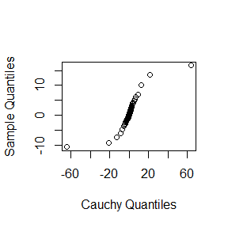

```r
set.seed(0)
m <- 10000
x <- numeric(m)
#提议分布用正态分布
x[1] <- rnorm(1)
k <- 0
u <- runif(m)
for (i in 2:m) {
  xt <- x[i-1]
  y <- rnorm(1, mean=xt)
  num <- dcauchy(y)
  den <- dcauchy(xt)
  if (u[i] <= num/den) x[i] <- y else {
    x[i] <- xt
    k <- k+1 #y is rejected
  }
}

x<-x[-(1:1000)]
a <- ppoints(100)
QR <- qcauchy(a) #quantiles of Cauchy
Q <- quantile(x, a)
qqplot(QR, Q, main="",
       xlab="Cauchy Quantiles", ylab="Sample Quantiles")
```

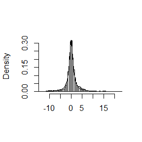

```r
hist(x, breaks="scott", main="", xlab="", freq=FALSE)
lines(QR,dcauchy(QR))
```

```r
a <- c(.05, seq(.1, .9, .1), .95)
Q <- qcauchy(a)
Qx<-quantile(x,a)
print(round(cbind(Q,Qx),3))
```

```
##          Q     Qx
## 5%  -6.314 -4.207
## 10% -3.078 -2.053
## 20% -1.376 -0.997
## 30% -0.727 -0.530
## 40% -0.325 -0.193
## 50%  0.000  0.108
## 60%  0.325  0.427
## 70%  0.727  0.857
## 80%  1.376  1.567
## 90%  3.078  3.530
## 95%  6.314  5.728
```

# 9.8

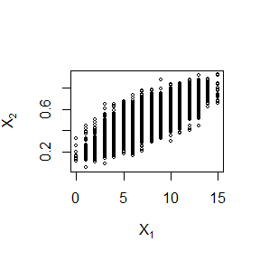

```r
set.seed(1)
#initialize constants and parameters
N <- 5000 #length of chain
burn <- 1000 #burn-in length
X <- matrix(0, N, 2) #the chain, a bivariate sample

n<-15
a<-5
b<-5
X[1,]<-c(1,0.3)
for (i in 2:N) {
  x2 <- X[i-1, 2]
  X[i, 1] <- rbinom(1, n, x2)
  x1 <- X[i, 1]
  X[i, 2] <- rbeta(1, x1+a, n-x1+b)
}
x <- X[(burn+1):N, ]

plot(x, main="", cex=.5, xlab=bquote(X[1]),
     ylab=bquote(X[2]), ylim=range(x[,2]))
```

# 9.3(cont.)

```r
set.seed(1)
Gelman.Rubin <- function(psi) {
  # psi[i,j] is the statistic psi(X[i,1:j])
  # for chain in i-th row of X
  psi <- as.matrix(psi)
  n <- ncol(psi)
  k <- nrow(psi)
  psi.means <- rowMeans(psi) #row means
  B <- n * var(psi.means) #between variance est.
  psi.w <- apply(psi, 1, "var") #within variances
  W <- mean(psi.w) #within est.
  v.hat <- W*(n-1)/n + (B/n) #upper variance est.
  r.hat <- v.hat / W #G-R statistic
  return(r.hat)
}
cauchy.chain <- function(N, X1) {
  #generates a Metropolis chain for Cauchy(0,1)
  #with N(X[t], 1) proposal distribution
  #and starting value X1
  x <- rep(0, N)
  x[1] <- X1
  u <- runif(N)
  for (i in 2:N) {
    xt <- x[i-1]
    y <- rnorm(1, mean=xt,sd=1)
    num <- dcauchy(y)
    den <- dcauchy(xt)
    if (u[i] <= num/den) x[i] <- y else {
      x[i] <- xt
      k <- k+1 #y is rejected
    }
  }
  return(x)
}
k <- 4 #number of chains to generate
n <- 20000 #length of chains
b <- 1000 #burn-in length
#choose overdispersed initial values
x0 <- c(-20, -10, 10, 20)
#generate the chains
X <- matrix(0, nrow=k, ncol=n)
for (i in 1:k){
  X[i, ] <- cauchy.chain(n, x0[i])
}

#compute diagnostic statistics
psi <- t(apply(X, 1, cumsum))
for (i in 1:nrow(psi)){
  psi[i,] <- psi[i,] / (1:ncol(psi))
}

print(Gelman.Rubin(psi))
```

```
## [1] 1.262184
```

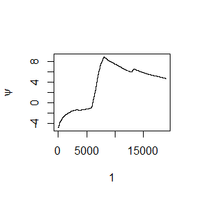

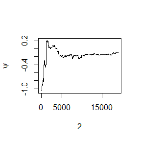

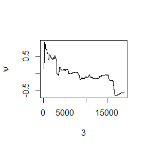

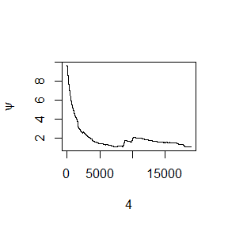

```r
#plot psi for the four chains

for (i in 1:k){
  plot(psi[i, (b+1):n], type="l",
       xlab=i, ylab=bquote(psi))
}
```

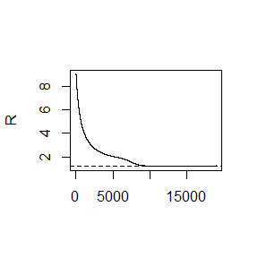

```r
#plot the sequence of R-hat statistics
rhat <- rep(0, n)
for (j in (b+1):n){
  rhat[j] <- Gelman.Rubin(psi[,1:j])
}

plot(rhat[(b+1):n], type="l", xlab="", ylab="R")
abline(h=1.2, lty=2)
```

```r
min(which(rhat[(b+1):n]<=1.2))
```

```
## [1] 10805
```

可以看到链从一万左右个样本开始收敛.我们运行这个链.

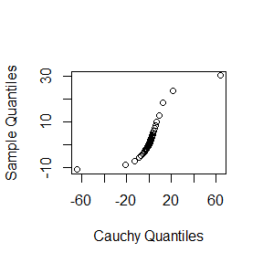

```r
set.seed(1)
n<-min(which(rhat[(b+1):n]<=1.2))+b
x<-cauchy.chain(n,-10)
x<-x[-(1:1000)]
a <- ppoints(100)
QR <- qcauchy(a) #quantiles of Cauchy
Q <- quantile(x, a)
qqplot(QR, Q, main="",
       xlab="Cauchy Quantiles", ylab="Sample Quantiles")
```

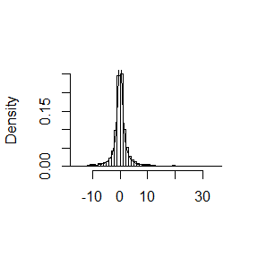

```r
hist(x, breaks="scott", main="", xlab="", freq=FALSE)
lines(QR,dcauchy(QR))
```

```r
a <- c(.05, seq(.1, .9, .1), .95)
Q <- qcauchy(a)
Qx<-quantile(x,a)
print(round(cbind(Q,Qx),3))
```

```
##          Q     Qx
## 5%  -6.314 -4.568
## 10% -3.078 -2.480
## 20% -1.376 -1.142
## 30% -0.727 -0.583
## 40% -0.325 -0.221
## 50%  0.000  0.092
## 60%  0.325  0.427
## 70%  0.727  0.891
## 80%  1.376  1.770
## 90%  3.078  4.141
## 95%  6.314  9.249
```

也看不太出哪里收敛了.

# 9.8(cont.)

```r
set.seed(3)

bivariate.chain<-function(N,X1,n=15,a=5,b=5){
  X <- matrix(0, N, 2) #the chain, a bivariate sample
  X[1,]<-X1
  for (i in 2:N) {
    x2 <- X[i-1, 2]
    X[i, 1] <- rbinom(1, n, x2)
    x1 <- X[i, 1]
    X[i, 2] <- rbeta(1, x1+a, n-x1+b)
  }
  return(X)
}
k<-4
n<-30000
b<-1000
x0 <- matrix(c(1,3,5,10,0.2,0.4,0.6,0.8),4,2)

Xone <- matrix(0, nrow=k, ncol=n)
for (i in 1:k){
  Xone[i, ] <- bivariate.chain(n, x0[i,])[,1]
}
psione <- t(apply(Xone, 1, cumsum))
for (i in 1:nrow(psione)){
  psione[i,] <- psione[i,] / (1:ncol(psione))
}
print(Gelman.Rubin(psione))
```

```
## [1] 1.454496
```

```r
rhatone <- rep(0, n)
for (j in (b+1):n){
  rhatone[j] <- Gelman.Rubin(psione[,1:j])
}

Xtwo <- matrix(0, nrow=k, ncol=n)
for (i in 1:k){
  Xtwo[i, ] <- bivariate.chain(n, x0[i,])[,2]
}
psitwo <- t(apply(Xtwo, 1, cumsum))
for (i in 1:nrow(psitwo)){
  psitwo[i,] <- psitwo[i,] / (1:ncol(psitwo))
}
print(Gelman.Rubin(psitwo))
```

```
## [1] 1.118843
```

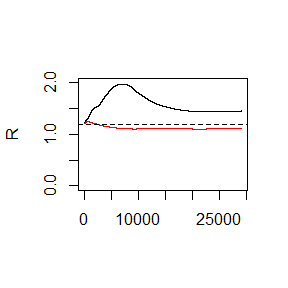

```r
rhattwo <- rep(0, n)
for (j in (b+1):n){
  rhattwo[j] <- Gelman.Rubin(psitwo[,1:j])
}



plot(rhatone[(b+1):n], type="l", xlab="", ylab="R",col=1,ylim=c(0,2))
lines(rhattwo[(b+1):n],col=2)
abline(h=1.2, lty=2)
```

这破玩意儿搞半天也不收敛，就这样吧

## HW9

## Question

Exercises 11.3 and 11.5

Suppose $T_1, . . . , T_n $are $i.i.d.$ samples drawn from the exponential distribution with expectation $\lambda$. Those values greater than $\tau$ are not observed due to right censorship, so that the observed values are$ Y_i = T_iI(T_i ≤ τ ) + I(T_i > ), i = 1, . . . , n. $Suppose $\tau = 1$ and the observed Yi values are as follows:
$$0.54, 0.48, 0.33, 0.43, 1.00, 1.00, 0.91, 1.00, 0.21, 0.85$$
Use the E-M algorithm to estimate λ, compare your result with the observed data MLE (note: Yi follows a mixture distribution)

## Answer

# 11.3

### (a)

```r
ak<-function(k,d=2,a=c(1,2)){
  result<-sum(a^2)/factorial(k)*(-sum(a^2)/2)^k*(1/(2*k+1)-1/(2*k+2))*exp(lgamma((d+1)/2)+lgamma(k+3/2)-lgamma(k+d/2+1))
  return(result)
}
```

### (b)

```r
Sn<-function(d=2,a=c(1,2),epsilon=1e-7){
k<-1
sn<-0
while (abs(ak(k,d=d,a=a))>=1e-7) {
  k<-k+1
  sn<-sn+ak(k,d=d,a=a)
}
return(sn)
}
```

### (c)

```r
Sn(d=2,a=c(1,2))
```

```
## [1] 0.1822609
```

# 11.5

k=500,1000时,error了.

```r
K<-c(4:25,100)
B <- rep(0,length(K))
i<-1
for(k in K){
  ck<-exp(log(2) + lgamma(k/2) - (1/2)*(log(pi*(k-1))) - lgamma((k-1)/2))
  ckk<-exp(log(2) + lgamma((k+1)/2) - (1/2)*(log(pi*(k))) - lgamma((k)/2))
  f<- function(a){
    return((ck*integrate(function(x)(1 + (x^2)/(k-1))^(-k/2), lower = 0, upper = sqrt((a^2)*(k-1)/(k-a^2)))$value) - (ckk*integrate(function(x)(1 + (x^2)/k)^(-(k+1)/2), lower = 0,upper = sqrt((a^2)*k/(k+1-a^2)))$value))
  }
  B[i] <- uniroot(f, lower = 0.01, upper = 1+sqrt(k)/2)$root
  i<-i+1
}
```

11.4,还是k=500,1000时有error

```r
K<-c(4:25, 100)
BB<-rep(0,length(K))
i<-1
for(k in K){
  ck<-exp(log(2) + lgamma(k/2) - (1/2)*(log(pi*(k-1))) - lgamma((k-1)/2))
  ckk<-exp(log(2) + lgamma((k+1)/2) - (1/2)*(log(pi*(k))) - lgamma((k)/2))
  g <- function(a){
    return((ck*integrate(function(x)(1 + (x^2)/(k-1))^(-k/2),
                           lower = sqrt((a^2)*(k-1)/(k-a^2)), upper = Inf)$value) - (ckk*integrate(function(x)(1 + (x^2)/k)^(-(k+1)/2),
                                                                                                      lower = sqrt((a^2)*k/(k+1-a^2)), upper = Inf)$value))
  }
  BB[i] <- uniroot(f, lower = 0.01, upper = 1+sqrt(k)/2)$root
  i<-i+1
}
cbind(K,B,BB)
```

```
##         K        B       BB
##  [1,]   4 1.492103 1.492103
##  [2,]   5 1.533576 1.533576
##  [3,]   6 1.562721 1.562721
##  [4,]   7 1.584427 1.584427
##  [5,]   8 1.601166 1.601166
##  [6,]   9 1.614524 1.614524
##  [7,]  10 1.625385 1.625385
##  [8,]  11 1.634415 1.634415
##  [9,]  12 1.642027 1.642027
## [10,]  13 1.648536 1.648536
## [11,]  14 1.654175 1.654175
## [12,]  15 1.659097 1.659097
## [13,]  16 1.663408 1.663408
## [14,]  17 1.667301 1.667301
## [15,]  18 1.670724 1.670724
## [16,]  19 1.673819 1.673819
## [17,]  20 1.676589 1.676589
## [18,]  21 1.679154 1.679154
## [19,]  22 1.681470 1.681470
## [20,]  23 1.683610 1.683610
## [21,]  24 1.685548 1.685548
## [22,]  25 1.687347 1.687347
## [23,] 100 1.720610 1.720610
```